# MDA2025-U7_Losungen

```python
import numpy as np
import matplotlib.pyplot as plt
import matplotlib.cm as cm

import warnings
warnings.filterwarnings(action='ignore')
```

Aufwärmaufgaben

*a)* $ \dot{x}_1 = \lambda x_1$

Mittels Trennen der Variablen ergibt sich: $\dfrac{dx_1}{x_1} = \lambda dt \;\;\Rightarrow\;\; \ln|x_1|=\lambda t + c \;\;\Rightarrow\;\; |x_1| = e^{\lambda t}e^c \;\;\Rightarrow\;\; x_1 = ke^{\lambda t}$

*b)* $\left[\begin{array}{c} \dot{x}_1 \\ \dot{x}_2 \end{array}\right] = \left[\begin{array}{c} \lambda_1 & 0 \\ 0 & \lambda_2 \end{array}\right]\left[\begin{array}{c} x_1 \\ x_2 \end{array}\right] \;\;\Rightarrow\;\; \begin{array}{l} \dot{x}_1=\lambda_1 x_1 \\ \dot{x}_2=\lambda_2 x_2\end{array} \;\;\Rightarrow\;\; \begin{array}{l} x_1=k_1 e^{\lambda_1 t} \\ x_2=k_2 e^{\lambda_2 t} \end{array}$

*c)* $\left[\begin{array}{c} \dot{x}_1 \\ \dot{x}_2 \end{array}\right] = \left[\begin{array}{c} \lambda & 1 \\ 0 & \lambda \end{array}\right]\left[\begin{array}{c} x_1 \\ x_2 \end{array}\right] \;\;\Rightarrow\;\; \begin{array}{lr} \dot{x}_1=\lambda x_1 +&x_2 \\ \dot{x}_2=&\lambda x_2\end{array} \;\;\Rightarrow\;\; \begin{array}{l}\\ x_2=k_2e^{\lambda t}\end{array} \;\;\Rightarrow\;\; \begin{array}{l} \dot{x}_1 = \lambda x_1 + k_2e^{\lambda t}\\\; \end{array} \;\;\Rightarrow\;\; \begin{array}{l} x_1 = (k_2 t+k_1) e ^{\lambda t}\\\; \end{array}$

Inhomogene lineare Differentialgleichung: $$\dot{x}_1 = \lambda x_1 +k_2e^{\lambda t}$$ Homogene Differentialgleichung: $$\dot{x}_1 = \lambda x_1 \;\;\Rightarrow\;\; x_1 = c e^{\lambda t}$$ Variation der Konstanten: $$x_1 = c(t) e^{\lambda t} \;\;\Rightarrow\;\;\dot{x}_1 = \dot{c}(t)e^{\lambda t} + c(t)\lambda e^{\lambda t}$$

Im Vergleich zur ursprünglichen inhomogenen Gleichung: $$\lambda \underbrace{c(t)e^{\lambda t}}_{x_1} +k_2e^{\lambda t} = \dot{c}(t)e^{\lambda t} + c(t)\lambda e^{\lambda t} \;\;\Rightarrow\;\; \dot{c}=k_2 \;\;\Rightarrow\;\; c(t) = k_2t+k_1$$

*d)* $\left[\begin{array}{c} \dot{x}_1 \\ \dot{x}_2 \end{array}\right] = \left[\begin{array}{c} 1 & 2 \\ 3 & 2 \end{array}\right]\left[\begin{array}{c} x_1 \\ x_2 \end{array}\right]$, Zusätzlich ist gegeben, dass $x_1 = 2e^{4t}+3e^{-t}$. Berechnen Sie $x_2$.

Die erste Gleichung ist: $\dot{x}_1 = x_1+2x_2 \;\;\Rightarrow\;\; x_2 = \frac12(\dot{x}_1-x_1) \;\;\Rightarrow\;\; x_1 = \frac12 ( 8e^{4t}-3e^{-t}-2e^{4t}-3e^{-t} ) = 3e^{4t}-3e^{-t}$

*e)* $\left[\begin{array}{c} \dot{x}_1 \\ \dot{x}_2 \end{array}\right] = \left[\begin{array}{c} 2 & -1 \\ -4 & 2 \end{array}\right]\left[\begin{array}{c} x_1 \\ x_2 \end{array}\right]$

**homogene Lösung**

$$\left[\begin{array}{c} \dot{x}_1 \\ \dot{x}_2 \end{array}\right] = \left[\begin{array}{c} 2 & -1 \\ -4 & 2 \end{array}\right]\left[\begin{array}{c} x_1 \\ x_2 \end{array}\right] $$

Bestimmung der Eigenwerte mittels $\mathrm{det}\left(\mathbf{A} - \lambda \mathbf{I}\right) = 0$

$$\mathrm{det}\left(\left[\begin{array}{c} 2 - \lambda & -1 \\ -4 & 2 -\lambda \end{array}\right]\right) = (2-\lambda)^2 - (-4) \cdot (-1) = \lambda^2 - 4\lambda = \lambda(\lambda-4)=0$$

mit den Lösungen $\lambda_1 = 0$ und $\lambda_2 = 4$. Eigenvektor für den Eigenwert $\lambda_1$ ergibt sich aus

$$ \left[\begin{array}{c} 2-\lambda_1 & -1 \\ -4 & 2-\lambda_1 \end{array}\right]\left[\begin{array}{c} v_1 \\ v_2 \end{array}\right] =\left[\begin{array}{c} 2 & -1 \\ -4 & 2 \end{array}\right]\left[\begin{array}{c} v_1 \\ v_2 \end{array}\right] = \left[\begin{array}{c} 0 \\ 0 \end{array}\right]$$

Man sieht, dass die Zeilen/Spalten in $\mathbf{A}$ linear abhängig sind, daher enthält die Lösungsmenge des linearen Gleichungssystems unendliche viele Lösungen. Es ergibt sich

$$2 v_1 -v_2 = 0 \; \rightarrow \; v_2 = 2v_1 \text{ mit } v_1 \in \mathbb{R}$$

Ein beliebiger Eigenvektor für $\lambda_1$ ergibt sich aus der Wahl $v_1=1$

$$\mathbf{\vec{ev}_1} = \left[\begin{array}{c} 1 \\ 2 \end{array}\right]$$

Für den zweiten Eigenwert $\lambda_2$ ergibt sich ein Eigenvektor aus

$$ \left[\begin{array}{c} 2-\lambda_2 & -1 \\ -4 & 2-\lambda_2 \end{array}\right]\left[\begin{array}{c} v_1 \\ v_2 \end{array}\right] =\left[\begin{array}{c} -2 & -1 \\ -4 & -2 \end{array}\right]\left[\begin{array}{c} v_1 \\ v_2 \end{array}\right] = \left[\begin{array}{c} 0 \\ 0 \end{array}\right]$$

Auch hier ensteht eine Koeffizientenmatrix mit linear abhängigen Spalten/Zeilen. Aus der 1. Gleichung ergibt sich

$$-2 v_1 - v_2 = 0 \; \rightarrow \; v_2 = -2 v_1 \text{ mit } v_1 \in \mathbb{R}$$

Ein Eigenvektor, für $v_1 = 1$, ist dann

$$\mathbf{\vec{ev}_2} = \left[\begin{array}{c} 1 \\ -2 \end{array}\right]$$

Die (homogene) Lösung der DGLn ist dann

$$\mathbf{\vec{x}_h} = c_1 \mathbf{\vec{ev}_1} \mathrm{e}^{\lambda_1 t} + c_2 \mathbf{\vec{ev}_2} \mathrm{e}^{\lambda_2 t} = c_1 \left[\begin{array}{c} 1 \\ 2 \end{array}\right]\mathrm{e}^{0 \cdot t} + c_2 \left[\begin{array}{c} 1 \\ -2 \end{array}\right] \mathrm{e}^{4 t} = c_1 \left[\begin{array}{c} 1 \\ 2 \end{array}\right] + c_2 \left[\begin{array}{c} 1 \\ -2 \end{array}\right] \mathrm{e}^{4 t}$$

Ausgeschrieben als einzelne Funktionen ergibt sich

$$x_1 = c_1 + c_2 \mathrm{e}^{4 t} \; \text{ und } \; x_2 = 2c_1 - 2c_2 \mathrm{e}^{4 t}$$

*Überprüfung*

Bilden der Ableitung der Lösung

$$ \mathbf{\dot{\vec{x}}} = 4 c_2 \left[\begin{array}{c} 1 \\ -2 \end{array}\right] \mathrm{e}^{4 t}$$

Einsetzen in DGLn $$ 4 c_2 \left[\begin{array}{c} 1 \\ -2 \end{array}\right] \mathrm{e}^{4 t} = \left[\begin{array}{c} 2 & -1 \\ -4 & 2 \end{array}\right]\left(c_1 \left[\begin{array}{c} 1 \\ 2 \end{array}\right] + c_2 \left[\begin{array}{c} 1 \\ -2 \end{array}\right] \mathrm{e}^{4 t}\right) = c_1 \left[\begin{array}{c} 0 \\ 0 \end{array}\right] + c_2 \left[\begin{array}{c} 4 \\ -8 \end{array}\right]\mathrm{e}^{4 t}$$

```
Eigenvalues: [4. 0.]
Eigenvectors: [[ 0.4472136   0.4472136 ]
 [-0.89442719  0.89442719]]
```

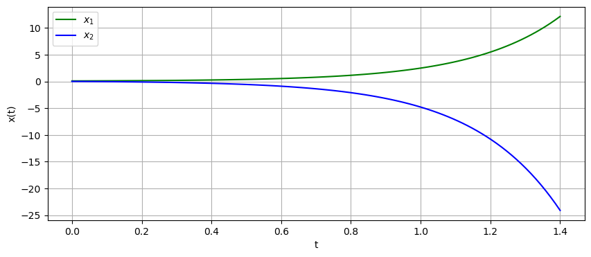

```python
A = np.array([[2, -1], [-4,2]])
eigenvalues, eigenvectors = np.linalg.eig(A) # spectral decomposition is A = V*D*inv(V), where V==eigenvectors and D = np.diag(eigenvalues)
print("Eigenvalues:", eigenvalues)
print("Eigenvectors:", eigenvectors)

t = np.linspace(0,1.4,101)
c1 = 0.1
c2 = 0.1
x1 = c1*eigenvectors[0,0]*np.exp(eigenvalues[0]*t) + c1*eigenvectors[0,1]*np.exp(eigenvalues[1]*t);
x2 = c1*eigenvectors[1,0]*np.exp(eigenvalues[0]*t) + c1*eigenvectors[1,1]*np.exp(eigenvalues[1]*t);

fig,ax = plt.subplots(1,1,figsize=(10,4))
ax.plot(t,x1,color='green', label='$x_1$')
ax.plot(t,x2,color='blue', label='$x_2$')
ax.grid()
ax.legend()
ax.set_xlabel('t')
ax.set_ylabel('x(t)')
plt.show()
```

*f)* $\left[\begin{array}{c} y_1^\prime \\ y_2^\prime \end{array}\right] = \left[\begin{array}{c} 7 & -1 \\ 5 & 5 \end{array}\right]\left[\begin{array}{c} y_1 \\ y_2 \end{array}\right]$ mit $\mathbf{\vec{y}}(0) = \left[\begin{array}{c} 2 \\ 0 \end{array}\right]$

**homogene Lösung**

$$\left[\begin{array}{c} y_1^\prime \\ y_2^\prime \end{array}\right] = \left[\begin{array}{c} 7 & -1 \\ 5 & 5 \end{array}\right]\left[\begin{array}{c} y_1 \\ y_2 \end{array}\right] $$

Bestimmung der Eigenwerte mittels $\mathrm{det}\left(\mathbf{A} - \lambda \mathbf{I}\right) = 0$

$$ (7 - \lambda)(5-\lambda) - 5 \cdot(-1) = \lambda^2 - 12\lambda + 40 = 0$$

Die Lösung für $\lambda$ ist

$$\lambda_{1/2} = 6 \pm \sqrt{36 - 40} = 6 \pm 2i$$

Für den Eigenwert $\lambda = 6 + 2i$ ergibt sich der zugehörige Eigenvektor aus

$$\left[\begin{array}{c} 1-2i & -1 \\ 5 & -1 -2i \end{array}\right] \left[\begin{array}{c} v_1 \\ v_2 \end{array}\right] = \left[\begin{array}{c} 0 \\ 0 \end{array}\right]$$

Die Lösung des linearen Gleichungssystem ist

$$(1-2i)v_1 - v_2 = 0 \; \rightarrow \; v_2 = (1-2i)v_1$$

und $$5v_1 - (1+2i)v_2 = 0 \; \rightarrow \; 5 v_1 - (1+2i)(1-2i)v_1 = 0 \cdot v_1 = 0 \; \rightarrow \; v_1 \in \mathbb{R}$$

Der zugehörige Eigenvektor mit $v_1 =1$ ist

$$\mathbf{\vec{ev}_1} = \left[\begin{array}{c} 1 \\ 1-2i \end{array}\right]$$

Für den Eigenwert $\lambda = 6 - 2i$ ergibt sich der zugehörige Eigenvektor aus

$$\left[\begin{array}{c} 1+2i & -1 \\ 5 & -1 +2i \end{array}\right] \left[\begin{array}{c} v_1 \\ v_2 \end{array}\right] = \left[\begin{array}{c} 0 \\ 0 \end{array}\right]$$

Die Lösung des linearen Gleichungssystem ist

$$(1+2i)v_1 - v_2 = 0 \; \rightarrow \; v_2 = (1+2i)v_1$$

und $$5v_1 + (-1+2i)v_2 = 0 \; \rightarrow \; 5 v_1 + (-1+2i)(1+2i)v_1 = 0 \cdot v_1 = 0 \; \rightarrow \; v_1 \in \mathbb{R}$$

und damit der 2. Eigenvektor mit $v_1 =1$ als

$$\mathbf{\vec{ev}_2} = \left[\begin{array}{c} 1 \\ 1+2i \end{array}\right]$$

Die homogene Lösung ist dann

$$\mathbf{\vec{y}_h} = c_1\left[\begin{array}{c} 1 \\ 1-2i \end{array}\right] \mathrm{e}^{(6 + 2i)x} + c_2 \left[\begin{array}{c} 1 \\ 1+2i \end{array}\right] \mathrm{e}^{(6 - 2i)x}$$

bzw.

$$\mathbf{\vec{y}_h} = c_1\left[\begin{array}{c} 1 \\ 1-2i \end{array}\right] \mathrm{e}^{6x} (\cos(2x) + i\sin(2x)) + c_2 \left[\begin{array}{c} 1 \\ 1+2i \end{array}\right] \mathrm{e}^{6x} (\cos(2x) - i\sin(2x))$$

Diese kann durch weitere Umformungen auf die Form $$y_1 = \mathrm{e}^{6x}\left[A \cos(2x) + B \sin(2x)\right]\; \text{ und } \;y_2 = \mathrm{e}^{6x}\left[(A-2B) \cos(2x) + (B+2A) \sin(2x)\right]$$ mit $A=c_1 + c_2$ und $B=i(c_1 - c_2)$ gebracht werden.

*Überprüfung*

Ableitung der homogenen Lösung

$$\mathbf{\vec{y}_h}^\prime = (6+2i)c_1\left[\begin{array}{c} 1 \\ 1-2i \end{array}\right] \mathrm{e}^{(6 + 2i)x} + (6-2i)c_2 \left[\begin{array}{c} 1 \\ 1+2i \end{array}\right] \mathrm{e}^{(6 - 2i)x}$$

Einsetzen in die DGL

$$(6+2i)c_1\left[\begin{array}{c} 1 \\ 1-2i \end{array}\right] \mathrm{e}^{(6 + 2i)x} + (6-2i)c_2 \left[\begin{array}{c} 1 \\ 1+2i \end{array}\right] \mathrm{e}^{(6 - 2i)x} = \left[\begin{array}{c} 7 & -1 \\ 5 & 5 \end{array}\right] \left(c_1\left[\begin{array}{c} 1 \\ 1-2i \end{array}\right] \mathrm{e}^{(6 + 2i)x} + c_2 \left[\begin{array}{c} 1 \\ 1+2i \end{array}\right] \mathrm{e}^{(6 - 2i)x}\right)$$

Division mit $ \mathrm{e}^{6x}$ und ausmultiplizieren führt auf

$$c_1\left[\begin{array}{c} 6+2i \\ 10 - 10i \end{array}\right] \mathrm{e}^{2ix} + c_2 \left[\begin{array}{c} 6-2i \\ 10 + 10i \end{array}\right] \mathrm{e}^{-2ix} = c_1 \left[\begin{array}{c} 7 - 1+2i \\ 5 + 5-10i \end{array}\right] \mathrm{e}^{2ix} + c_2 \left[\begin{array}{c} 7 - 1-2i\\ 5 + 5+10i \end{array}\right] \mathrm{e}^{- 2ix} $$

**Bestimmung der speziellen Lösung**

Aufstellen der Anfangsbedingung

$$c_1\left[\begin{array}{c} 1 \\ 1-2i \end{array}\right] \mathrm{e}^{(6 + 2i) \cdot 0} + c_2 \left[\begin{array}{c} 1 \\ 1+2i \end{array}\right] \mathrm{e}^{(6 - 2i) \cdot 0} = c_1\left[\begin{array}{c} 1 \\ 1-2i \end{array}\right] + c_2 \left[\begin{array}{c} 1 \\ 1+2i \end{array}\right] = \left[\begin{array}{c} 2 \\ 0 \end{array}\right]$$

weiter ausmultiplizieren ergibt

$$c_1\left[\begin{array}{c} 1 \\ 1-2i \end{array}\right] + c_2 \left[\begin{array}{c} 1 \\ 1+2i \end{array}\right] = \left[\begin{array}{c} c_1 + c_2 \\ c_1(1-2i) + c_2(1+2i) \end{array}\right] = \left[\begin{array}{c} 2 \\ 0 \end{array}\right]$$

aus der oberen Gleichung ergibt sich

$$c_1 + c_2 = 2 \; \rightarrow \; c_2 = 2 - c_1$$

und aus der unteren Gleichung ergibt sich anschließend $$ c_1(1-2i) + (2-c_1)(1+2i) = 2 + i4(1-c_1) = 0 \; \rightarrow c_1 = 1 + i \frac{1}{2}$$

Es ergibt sich als spezielle Lösung

$$\mathbf{\vec{y}_s} = \left(1 + i \frac{1}{2}\right)\left[\begin{array}{c} 1 \\ 1-2i \end{array}\right] \mathrm{e}^{(6 + 2i)x} + \left(1 - i \frac{1}{2}\right) \left[\begin{array}{c} 1 \\ 1+2i \end{array}\right] \mathrm{e}^{(6 - 2i)x}$$

bzw. in der reellen Darstellung mit $A = c_1 + c_2 = 2$ und $B= i(c_2 - c_1) = 1$

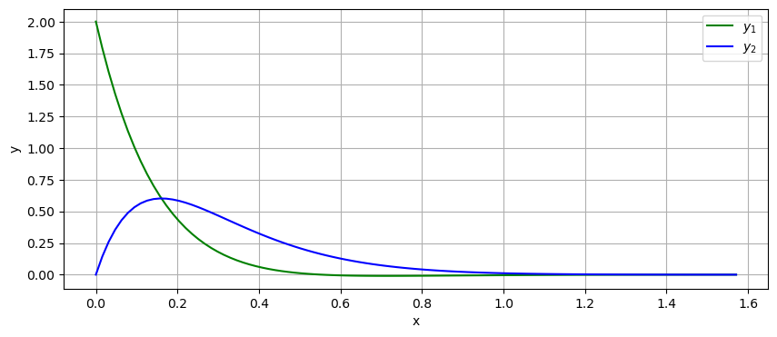

```python
x = np.linspace(0,np.pi/2,101)
y1 = np.exp(-6*x)*(2*np.cos(2*x) - np.sin(2*x))
y2 = 5*np.exp(-6*x)*np.sin(2*x)

fig,ax = plt.subplots(1,1,figsize=(10,4))
ax.plot(x,y1,color='green', label='$y_1$')
ax.plot(x,y2,color='blue', label='$y_2$')
ax.grid()
ax.legend()
ax.set_xlabel('x')
ax.set_ylabel('y')
plt.show()
```

*g)* $\left[\begin{array}{c} y_1^\prime \\ y_2^\prime \end{array}\right] = \left[\begin{array}{c} -3 & -2 \\ 2 & 1 \end{array}\right]\left[\begin{array}{c} y_1 \\ y_2 \end{array}\right] + \left[\begin{array}{c} 3x \\ 2x \end{array}\right]$

**homogene Lösung**

$$\left[\begin{array}{c} y_1^\prime \\ y_2^\prime \end{array}\right] = \left[\begin{array}{c} -3 & -2 \\ 2 & 1 \end{array}\right]\left[\begin{array}{c} y_1 \\ y_2 \end{array}\right] $$

Bestimmung der Eigenwerte mittels $\mathrm{det}\left(\mathbf{A} - \lambda \mathbf{I}\right) = 0$

$$ (-3 - \lambda)(1-\lambda) - 2 \cdot(-2) = \lambda^2 + 2\lambda + 1 = 0$$

Die Lösung für $\lambda$ ist

$$\lambda_{1/2} = -1$$

Bestimmung des Eigenvektors für den 1. Eigenwert

$$\left[\begin{array}{c} -2 & -2 \\ 2 & 2 \end{array}\right] \left[\begin{array}{c} v_1 \\ v_2 \end{array}\right] = \left[\begin{array}{c} 0 \\ 0 \end{array}\right]$$

Aus der Gleichung lässt sich ablesen $v_1 = -v_2$ und damit ist ein Eigenvektor $$\mathbf{\vec{ev}_1} = \left[\begin{array}{c} 1 \\ -1 \end{array}\right]$$

Da ein doppelter Eigenwert vorliegt, bestimmt sich der zweite Eigenvektor durch der Gleichung

$$\left(\mathbf{A} - \lambda \mathbf{I}\right) \mathbf{\vec{ev}_2} = \mathbf{\vec{ev}_1}$$

Mit den bekannten Größen ergibt sich

$$\left[\begin{array}{c} -2 & -2 \\ 2 & 2 \end{array}\right]\mathbf{\vec{ev}_2} = \left[\begin{array}{c} 1 \\ -1 \end{array}\right]$$

Die Lösung diese linearen Gleichungssystems ist (mit $\mathbf{\vec{ev}_2} = \left[\begin{array}{c} u_1 \\ u_2 \end{array}\right]$)

$$-2u_1 - 2u_2 = 1 \; \rightarrow \; u_2 = -u_1 - \frac{1}{2} \text{ mit } u_1 \in \mathbb{R}$$

mit $u_1=0$ ergibt sich

$$\mathbf{\vec{ev}_2} = \left[\begin{array}{c} 0 \\ - \frac{1}{2} \end{array}\right]$$

Die Lösung der homogenen DGL ist dann

$$\mathbf{\vec{y}_h} = c_1 \mathbf{\vec{ev}_1} \mathrm{e}^{\lambda x} + c_2 \left(\mathbf{\vec{ev}_1}x + \mathbf{\vec{ev}_2}\right) \mathrm{e}^{\lambda x} = c_1\left[\begin{array}{c} 1 \\ -1 \end{array}\right]\mathrm{e}^{-x} + c_2\left(\left[\begin{array}{c} 1 \\ -1 \end{array}\right] x + \left[\begin{array}{c} 0 \\ -\frac{1}{2} \end{array}\right] \right)\mathrm{e}^{-x}$$

beziehungsweise als einzelne Funktionen ausgedrückt

$$y_1 = \left(c_1 + c_2x\right)\mathrm{e}^{-x}\; \text{ und } \;y_2 = \left(-c_1 - \frac{c_2}{2} - c_2x\right)\mathrm{e}^{-x} $$

*Überprüfung*

Bilden der Ableitung

$$y_1^\prime = - \left(c_1 + c_2x\right)\mathrm{e}^{-x} + c_2\mathrm{e}^{-x} = \left(-c_1 - c_2x + c_2\right)\mathrm{e}^{-x} $$

und

$$y_2^\prime = -\left(-c_1 - \frac{c_2}{2} - c_2x\right)\mathrm{e}^{-x} - c_2\mathrm{e}^{-x} = \left(c_1 - \frac{c_2}{2} + c_2x\right)\mathrm{e}^{-x}$$

Einsetzen in das *homogene* DGL-System ergibt

$$ \left(-c_1 - c_2x + c_2\right)\mathrm{e}^{-x} = -3\left(c_1 + c_2x\right)\mathrm{e}^{-x} - 2\left(-c_1 - \frac{c_2}{2} - c_2x\right)\mathrm{e}^{-x}$$

und

$$\left(c_1 - \frac{c_2}{2} + c_2x\right)\mathrm{e}^{-x} = 2\left(c_1 + c_2x\right)\mathrm{e}^{-x} + \left(-c_1 - \frac{c_2}{2} - c_2x\right)\mathrm{e}^{-x}$$

Division mit $\mathrm{e}^{-x}$ führt jeweils auf

$$\left(-c_1 - c_2x + c_2\right) = -3c_1 - 3c_2x + 2c_1 + c_2 + 2c_2x = -c_1 + c_2 - c_2x$$

und

$$\left(c_1 - \frac{c_2}{2} + c_2x\right) = 2c_1 +2 c_2x -c_1 - \frac{c_2}{2} - c_2x = c_1 - \frac{c_2}{2} + c_2x$$

**partikuläre Lösung**

Störvektor ist

$$\mathbf{\vec{g}}(x) = \left[\begin{array}{c} 3x \\ 2x \end{array}\right]$$

Die gewählte Ansatzfunktion ist

$$\mathbf{\vec{y}_p} = \left[\begin{array}{c} a_0 \\ a_1 \end{array}\right] + \left[\begin{array}{c} a_2 \\ a_3 \end{array}\right]x$$

Ableitung der Ansatzfunktion

$$\mathbf{\vec{y}_p^\prime} =\left[\begin{array}{c} a_2 \\ a_3 \end{array}\right]$$

Einsetzen in DGL-System

$$\left[\begin{array}{c} a_2 \\ a_3 \end{array}\right] = \left[\begin{array}{c} -3 & -2 \\ 2 & 1 \end{array}\right]\left(\left[\begin{array}{c} a_0 \\ a_1 \end{array}\right] + \left[\begin{array}{c} a_2 \\ a_3 \end{array}\right]x\right) + \left[\begin{array}{c} 3x \\ 2x \end{array}\right] = \left[\begin{array}{c} -3 & -2 \\ 2 & 1 \end{array}\right]\left[\begin{array}{c} a_0 + a_2x \\ a_1 +a_3x \end{array}\right] + \left[\begin{array}{c} 3x \\ 2x \end{array}\right] $$

ergibt die Gleichungen

$$a_2 = (\underbrace{-3a_2 - 2a_3 +3}_{=0})x - 3a_0 - 2a_1$$

und $$a_3 = (\underbrace{2a_2 + a_3 + 2}_{=0})x + 2a_0 + a_1$$

Es ergibt sich folgendes lineares Gleichungssystem

$$\left[\begin{array}{c} 0 & 0 & -3 & -2 \\ 3 & 2 & 1 & 0 \\ 0 & 0 & 2 & 1\\ -2 & -1 & 0 & 1 \end{array}\right] \left[\begin{array}{c} a_0 \\ a_1 \\a_2\\ a_3 \end{array}\right] = \left[\begin{array}{c} -3 \\0 \\ -2 \\ 0 \end{array}\right]$$

mit den Lösungen

$$ \left[\begin{array}{c} a_0 \\ a_1 \\a_2\\ a_3 \end{array}\right] = \left[\begin{array}{c} 17 \\ -22 \\ - 7 \\ 12 \end{array}\right] $$

Die partikuläre Lösung ist dann

$$\mathbf{\vec{y}_p} = \left[\begin{array}{c} 17 \\ -22 \end{array}\right] + \left[\begin{array}{c} -7 \\ 12 \end{array}\right]x$$

*Überprüfung*

$$a_2 = (-3a_2 - 2a_3 +3)x - 3a_0 - 2a_1 \; \rightarrow \; -7 = (21 - 24 + 3)x - 51 + 44 = -7$$

und

$$a_3 = (2a_2 + a_3 + 2)x + 2a_0 + a_1 \; \rightarrow \; 12 = (-14 + 12 + 2)x + 34 -22 = 12$$

Die allgemeine Lösung ergibt zu

$$\mathbf{\vec{y}} = \mathbf{\vec{y}_h} + \mathbf{\vec{y}_p} = c_1\left[\begin{array}{c} 1 \\ -1 \end{array}\right]\mathrm{e}^{-x} + c_2\left(\left[\begin{array}{c} 1 \\ -1 \end{array}\right] x + \left[\begin{array}{c} 0 \\ -\frac{1}{2} \end{array}\right] \right)\mathrm{e}^{-x} + \left[\begin{array}{c} 17 \\ -22 \end{array}\right] + \left[\begin{array}{c} -7 \\ 12 \end{array}\right]x$$

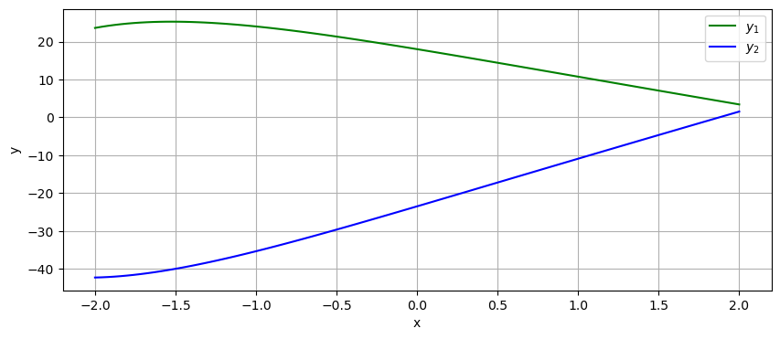

```python
x = np.linspace(-2,2,101)
c1 = 1
c2 = 1
y1 = c1*np.exp(-x) + c2*x*np.exp(-x) + 17 -7*x
y2 = -c1*np.exp(-x) - c2*x*np.exp(-x) - 0.5*c2*np.exp(-x) - 22 + 12*x

fig,ax = plt.subplots(1,1,figsize=(10,4))
ax.plot(x,y1,color='green', label='$y_1$')
ax.plot(x,y2,color='blue', label='$y_2$')
ax.grid()
ax.legend()
ax.set_xlabel('x')
ax.set_ylabel('y')
plt.show()
```